# Lab09NotTeamOne

David Orozco, Ethan Schacht, Ryan Tate, Anderson Mun, Arie del Valle

March 14, 2019

#### Team Plot

- Question: What parks did people bike to using bike station on the fourth of July?

[figure not shown]

```
## # A tibble: 11 x 2
##    `End station`                       n
##    <chr>                           <int>
##  1 Minnehaha Park                     76
##  2 Gateway Park                       40
##  3 Logan Park                         30
##  4 North Mississippi Regional Park    24
##  5 Loring Park                        21
##  6 Boom Island Park                   16
##  7 Elliot Park                        10
##  8 Fort Snelling State Park            8
##  9 Farview Park                        6
## 10 Currie Park                         5
## 11 Hidden Falls Park                   1
```

- Here you can see the plot of Ryan, showing all of the bike trips from bike stations to parks on the fourth of July, with added markers for each park. This plot is interesting because it shows the parks most popular on the 4th of July, maybe because they had fireworks or some other event going on. In addition, the plot shows the distribution of stations that people left from to get to these parks.

#### David’s Section

Question: How long do people keep bikes with NiceRide in terms of duration(time) and date-time??

```
## # A tibble: 4 x 4
##   SameDayReturn SameHourReturn      n  percent
##   <lgl>         <lgl>           <int>    <dbl>
## 1 TRUE          TRUE           322028 0.699
## 2 TRUE          FALSE          134857 0.293
## 3 FALSE         FALSE            3746 0.00813
## 4 FALSE         TRUE               87 0.000189
```

Note : `samedayreturn = false` includes those who rented before midnight and returns after midnight. This is not based on time (24hr) but on date.

- The tibble above shows the amount of NiceRide users depending on when they rented and returned thier bikes. Most users (~ 70%) rent and return thier bikes on the same day and hour. About 29% of users rent and return on the same day but return in during a different hour. The minority of the users, less than .02% , return thier bikes at the same time on different days.

The graphs below are based on time. Also, it is composed of 434,696 NiceRide users who rent thier bikes for less than hour.

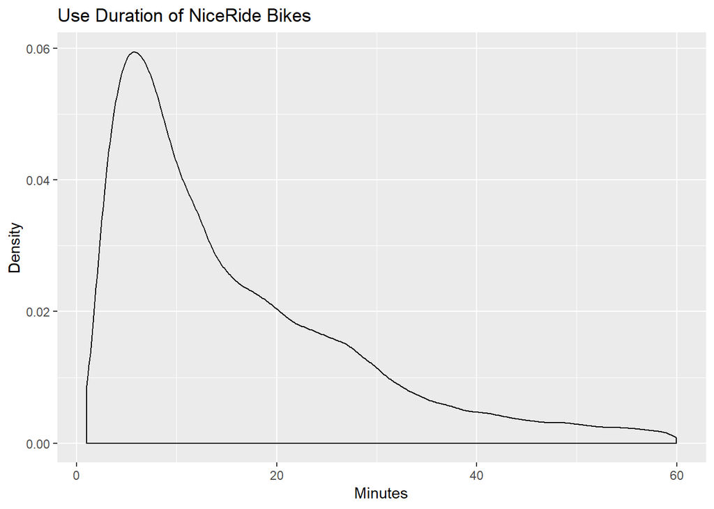

```
## # A tibble: 1 x 1
##        n
##    <int>
## 1 434696
```

```
## # A tibble: 1 x 1
##    mean
##   <dbl>
## 1  5.92
```

Methods: I used `left_join` to merge the location and ride dataset in order to be able to plot latitude and logitude along with date. I used `separate` to spit the date and times for `Start Date` and `End date`. I also used a tactic described in chapter 13 to find the amount of ‘repeats’. So I was able to find when `dateint == dateend` and/or `hourint == hourend`. I used the `myd()` function to format the character entries for date into a date format. Along with that function I used other `parse` functions to reformat the entries. `returns <- returns[,c(5,6,3,4)]` was used in place of `select` to elect the columns that were under study. Finally, I used `filter` commands and `geom_density` to show the distribution in duration of bikes rented.

#### Arie’s Section

- Question: What is the average lattitude traveled depending on the account type?

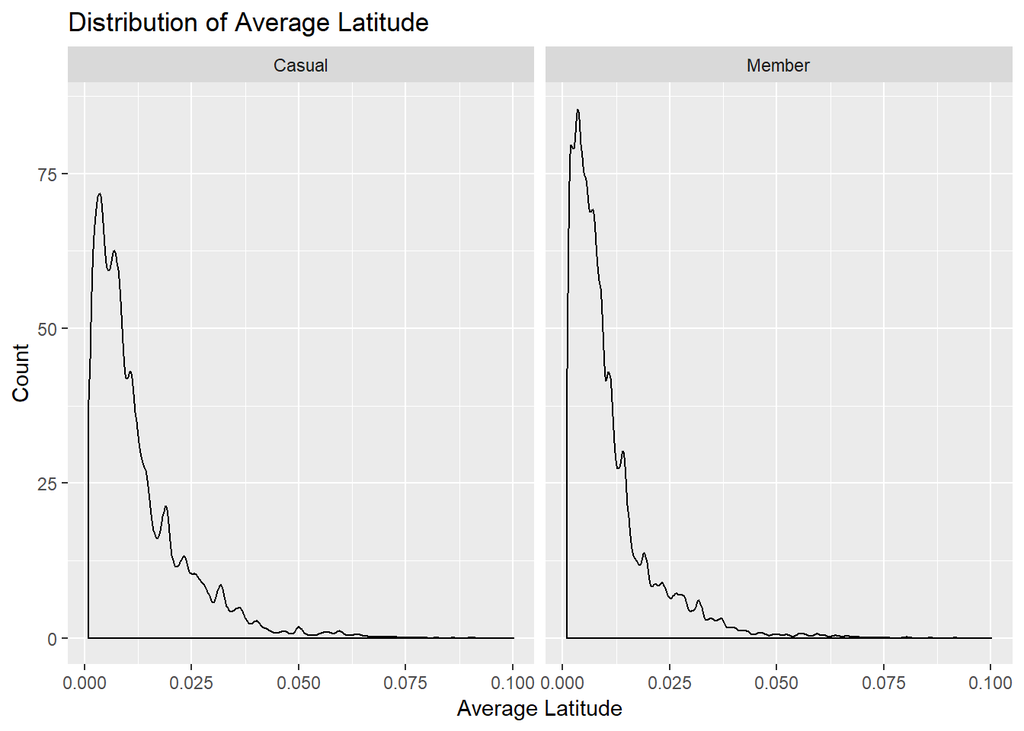

- Findings: From my graph I found that there was not much of a difference in the distribution of latitude traveled depedning on the account type. The trend of each account is pretty much the same. However, the distribution of memembers is more.
- I used `mutate()` to create new columns that show the total distance for latitude and longitude. Then I created a new varible and selected the data that I wanted to focus on. Then I used `filter()` the longitude and latitude that were greater than .001. Then I used `group_by()` and `summarise()` to find the average distance for latitude and longitude. After I created a `ggplot()` with the new data variable. I used `geom_denisty()` and `facet_wrap()` to compare the distribution by account type.

#### Anderson’s Section

- Question: What is the average duration a rider stays on their bike per month?

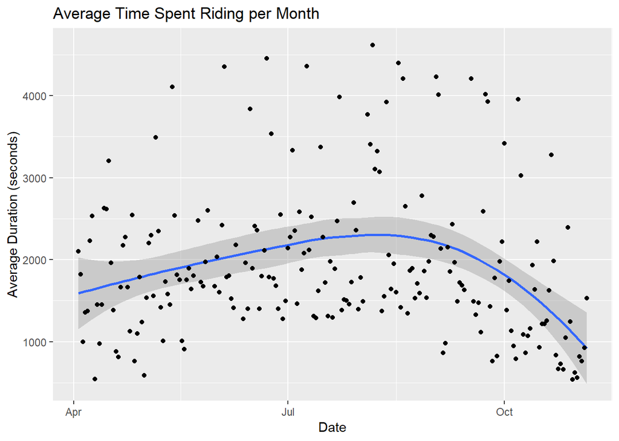

- In my finding I found out that the least amount of time spent riding a bike were during the coldest and latest months of the year. During the months in the middle of the year bikers on average had the longest duration.

#### Ethan’s Section

- Question: How often do people use the Nice Ride depending on the day of week, and how does this vary by account type?

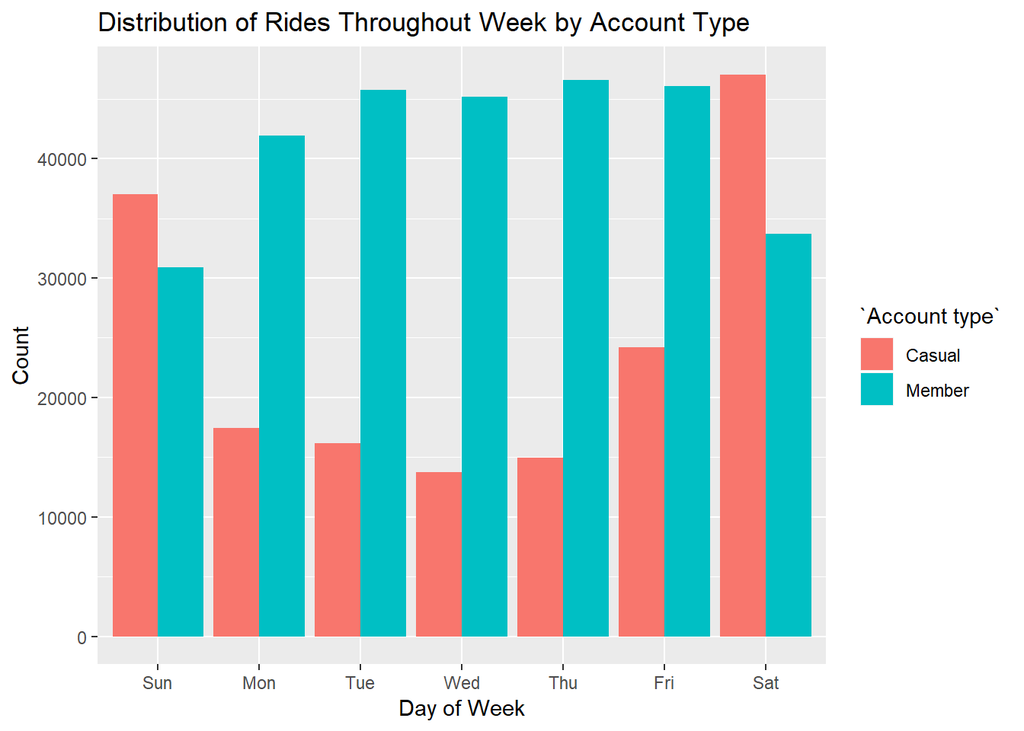

- Methods: I first used `left_join` to combine the locations dataset with the overall rides dataset, and then changed some variable names and sorted based on if the variables described starting location or ending location. I then parsed by times into `mdy_hm` and used `w_day` to make a variable describing the day of week. For the graph, used geom_bar to plot day of week against count of rides for that day of week, filling with Account Type and using `dodge` to compare the different memberships side-by-side for each day. To get stats from this graph, I grouped by the week day and account type and counted occurances of each combination.
- Findings: Most people tend to utilize the Nice Rides on the weekends, and this makes sense because people tend to have more free time on these days. Interestingly, member account types far outnumber casual account types on the weekdays, but casual account types outweigh member account types on the weekends. This is likely due to the fact that people who pay for the membership are likely doing so because they also need it on the weekdays, perhaps to regularly commute to work, whereas casual riders who may be using the service for more leisurely reasons on the weekends don’t as strongly require a regular membership.
- Stats:
1. The most common riding day is Saturday, with a total of over 80,000 rides
2. Totals of at least 40,000 rides are taken by members on each week day, and totals of less than 20,000 rides are taken by casual members each weekday unless it’s Friday

#### Ryan’s Section

Main quesitno: What parks did people bike to using bike station on the fourth of July?

Did people bike to one particlar park or multiple ones?

which park did most people bike to?

[figure not shown]

```
## # A tibble: 11 x 2
##    `End station`                       n
##    <chr>                           <int>
##  1 Minnehaha Park                     76
##  2 Gateway Park                       40
##  3 Logan Park                         30
##  4 North Mississippi Regional Park    24
##  5 Loring Park                        21
##  6 Boom Island Park                   16
##  7 Elliot Park                        10
##  8 Fort Snelling State Park            8
##  9 Farview Park                        6
## 10 Currie Park                         5
## 11 Hidden Falls Park                   1
```

- I worked on joining the datasets and finding out how to convert the dates to a datetime. I also filtered by date and by statiion ending in the work Park in order to find the trips to parks. I then used geom_segment to illustrate the bike stations people left from to get to the parks. Afterwards, I scaled the graph to focus on the trips to the popular parks in Minneapolis.
- findings: Most people biked to Minnehaha park, followed by Gateway park and Logan park. People biked to 11 parks in total.

#### Who did what?

- David - Team jokes and awesome wheelchair video, individual sectio, rMarkdown edits, mananged gitKraken errors, ploted points on team map, ran some openmap stuff with Ryan.
- Arie- Individual section
- Anderson- Individual section and findings, Seperated and tidied the dataset
- Ethan- ind section and findings, merged and tidied/sorted the two datasets
- Ryan- indivual section. Helped create team plot. filtered, plotted, and string detected